# 北美旅游

狗熊会

案例难度：***

案例背景：伴随互联网的普及，越来越多热爱旅游的驴友们开始选择在网上购买旅游产品，但是网上的旅游产品名目众多，面对一个相对陌生的旅行目的地，驴友们往往很难选择出最“物美价廉”的那一个、本案例通过对网上各种北美旅游产品的相关信息进行统计分析，帮助驴友们花更少的钱，购买最赞的北美旅游产品！

数据介绍：案例数据提供了2926条北美旅游数据观测，共25个变量，其中包括产品名称、旅游方式、供应商、等级、景点个数、交通情况、用餐情况、是否有自由活动、客户评分、出游人数、评价人数、报价信息、旅游线路等，详细解释请查看案例推文北美在线旅游产品选择攻略。

学习目标：

1. 了解旅游数据；

2. 对文本数据进行简单处理和描述分析。

## 准备工作

```r
cat("\014");rm(list=ls())  # 清除工作环境
```

```r
library(readxl)          # 读取.xlsx数据
library(dplyr)             # 用导管运算
library(ggplot2)           # 画ggplot图
library(stringr)           # 处理字符串
library(purrr)             # 使用map函数
```

## 任务一

读入数据，筛选出产品名称、旅游方式、供应商、等级、景点个数、交通、用餐、自由活动、总评价、出游人数、出发地、每日报价、旅游线路变量并重命名为英文变量名。

去除产品名称中带有“健康医疗”以及从国内出发（出发地为上海或北京）的样本。将数据集命名为travel_dat，查看数据的前几行。

```r
dat <- read_excel("travel.xlsx", 1)                                                         # 原始数据
travel_dat <- dat[,c(1:8,12:13,15,17:23,25)]                                               # 筛选出需要用到的变量
colnames(travel_dat) <- c("Product", "TravelMethod", "Agency", "Star",
                          "Place", "Traffic", "Meal","FreeActivitie",
                          "Evaluate","Sale","Depart","SunPrice","MonPrice",
                          "Tuesprice","WedPrice","ThusPrice",
                          "Friprice","Satprice","Routine")                                 # 将变量名改为英文
travel_dat <- travel_dat[!startsWith(as.character(travel_dat$Product),"健康医疗"),]        # 去除数据中有健康医疗字样的样本
travel_dat <- travel_dat[which(travel_dat$Depart != "上海"&travel_dat$Depart != "北京"),]  # 去除从国内出发的
head(travel_dat)                                                                           # 查看前几行
```

```
## # A tibble: 6 x 19
##   Product TravelMethod Agency Star  Place Traffic Meal  FreeActivitie
##   <chr>   <chr>        <chr>  <chr> <chr> <chr>   <chr> <chr>
## 1 美国洛杉矶+~ 跟团游       供应商：熊~ 5晚3钻~ 共7个景~ 暂无交通信息~ 暂无用餐~ 自由活动1次
## 2 美国西海岸+~ 跟团游       供应商：熊~ 9晚3钻~ 共14个~ 行车时长38~ 暂无用餐~ 自由活动1次
## 3 美国黄石国家~ 半自助游     供应商：途~ 暂无酒店~ 共12个~ 暂无交通信息~ 暂无用餐~ 暂无自由活动信息~
## 4 美国洛杉矶+~ 跟团游       供应商：N~ 4晚3钻~ 共11个~ 行车时长6小~ 暂无用餐~ 自由活动1次
## 5 美国洛杉矶+~ 半自助游     供应商：熊~ 暂无酒店~ 共54个~ 行车时长33~ 42次自~ 暂无自由活动信息~
## 6 美国拉斯维加~ 跟团游       供应商：熊~ 6晚3钻~ 共6个景~ 暂无交通信息~ 暂无用餐~ 自由活动1次
## # ... with 11 more variables: Evaluate <chr>, Sale <chr>, Depart <chr>,
## #   SunPrice <chr>, MonPrice <chr>, Tuesprice <chr>, WedPrice <chr>,
## #   ThusPrice <chr>, Friprice <chr>, Satprice <chr>, Routine <chr>
```

## 任务二

提取周一到周日报价中的数值部分，计算一周报价的均值（若一周7天均无报价则缺失），并以新变量“Price”存入数据集travel_dat中，剔除平均价格缺失的样本。绘制价格的对数分布直方图并进行简要解读。

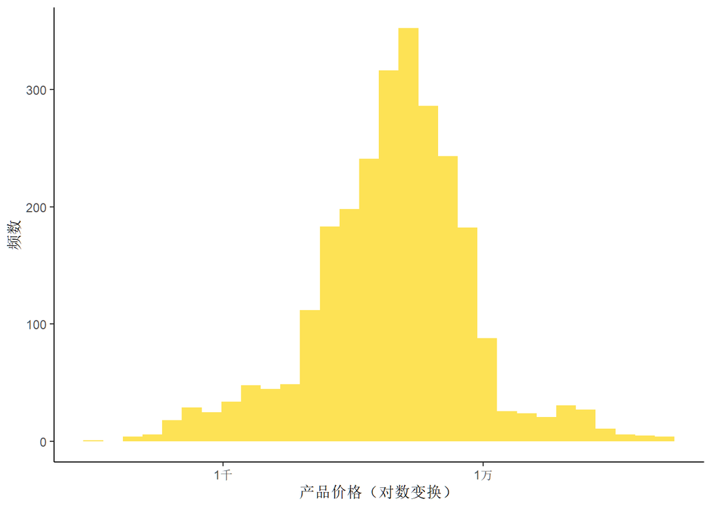

```r
allPrice <- travel_dat[,12:18]                              # 取出周一到周日的数据
allPrice[allPrice==""] <- NA                                # 处理缺失值

PriceToNum <- function(price)                               # 自定义函数，提取价格的数值部分
{
  price <- gsub("\\D", "", as.character(price)) %>%
    as.numeric()                                            # 去字符串中的价格部分
  return(price)
}

price <- allPrice %>% apply(2, PriceToNum)                  # 得到价格的数值部分

avgprice <- apply(price, 1, function(x) mean(x, na.rm = T)) # 平均价格
travel_dat$Price <- avgprice                                # 建立新变量价格
travel_dat <- travel_dat[!is.na(travel_dat$Price),]         # 去除缺失价格的观测

ggplot(travel_dat, aes(x = Price)) +
  geom_histogram(fill = adjustcolor("#FDE255")) +           # 直方图
  scale_x_log10(                                            # log变换
    breaks=c(1e3,1e4,1e5),
    labels=c("1千", "1万", "10万")) +                       # 改变坐标轴数值名称
  xlab("产品价格（对数变换）") + ylab("频数") +             # x轴y轴的label
  theme_classic()
```

## 任务三

从“Place”变量中提取出全部景点数和经典景点数，并分别以“AllPlace”和“ClassicPlace”变量存入数据集travel_dat，变量类型为数值型。

将全部景点数按由少到多分成4组，分别为“9个及以下”，“10-16个”，“17-25个”，“25个以上”，以变量“AllPlacesGroup”变量保存在数据集travel_dat中，计算每一组内产品的平均价格并使用dplyr包的summarise()函数进行展示。

```r
place <- travel_dat$Place %>% as.character()                                                  # 变成字符变量
travel_dat$AllPlace <- place %>% str_extract("[[:digit:]]+?(?=个景点)") %>% as.numeric()      # 得到所有景点个数
travel_dat$ClassicPlace <- place %>% str_extract("[[:digit:]]+?(?=个经典)") %>% as.numeric()  # 得到经典景点个数

travel_dat$AllPlacesGroup <- cut(travel_dat$AllPlace, breaks = c(0, 9, 16, 25, 77))           # 按景点个数数量分组

travel_dat %>% group_by(AllPlacesGroup) %>% summarise(mean(Price, na.rm=T))                   # 每组价格均值
```

```
## # A tibble: 5 x 2
##   AllPlacesGroup `mean(Price, na.rm = T)`
##   <fct>                             <dbl>
## 1 (0,9]                             4203.
## 2 (9,16]                            5300.
## 3 (16,25]                           6564.
## 4 (25,77]                           6981.
## 5 <NA>                              4596.
```

## 任务四

利用周一到周日是否有报价计算每周出团日期，若当天有报价则视为出团，无报价则为未出团。提取出“仅工作日”，“仅周末”，“工作日和周末”三类出团情况并以“Date”变量存入数据集travel_dat（不属于上述任何一种情况的以缺失值存储），计算每一类出团日期的平均价格并展示。

```r
## 得到周一到周日的产品价格
price1 <- allPrice[!is.na(avgprice),] %>% apply(2, PriceToNum)

## 仅工作日有团，周末无团
onlyweekday <- which(apply(price1, 1, function(y) (!all(is.na(y[2:6]))) & all(is.na(y[c(1,7)]))))

## 仅周末有团，工作日无团
onlyweekend <- which(apply(price1, 1, function(y) all(is.na(y[2:6])) & !all(is.na(y[c(1,7)]))))

## 周末和周末都有团
allweek <- which(apply(price1, 1, function(y) !all(is.na(y[2:6])) & !all(is.na(y[c(1,7)]))))

## 得到产品的出团日期
travel_dat$Date <- rep(NA,dim(travel_dat)[1])
travel_dat$Date[onlyweekday] <- "仅工作日"
travel_dat$Date[onlyweekend] <- "仅周末"
travel_dat$Date[allweek] <- "工作日和周末"
travel_dat$Date <- as.factor(travel_dat$Date)

## 不同出团日期的产品均价
travel_dat %>% group_by(Date) %>% summarise(mean = mean(Price))
```

```
## # A tibble: 3 x 2
##   Date          mean
##   <fct>        <dbl>
## 1 工作日和周末 5787.
## 2 仅工作日     5275.
## 3 仅周末       6929.
```

## 任务五

提取“Star”变量中的“*钻”字符来表示产品等级，当一个产品包含多个钻级时取最大钻级，并将产品钻级以新变量“my_star”存入数据集travel_dat中，变量类型为因子型。

绘制价格的对数对产品等级的分组箱线图，并按每一等级的平均价格由低到高进行排列，对箱线图结果作出简要解读。

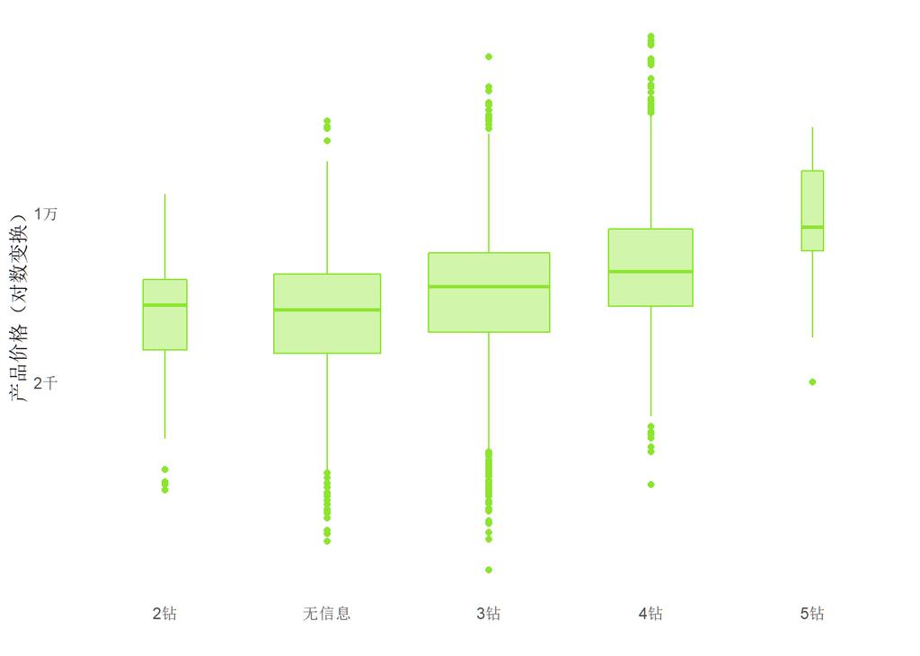

```r
star <- strsplit( as.character(travel_dat$Star), "\\,")         # 按“,”分开等级

StarNum <- function(x)                                          # 自定义函数，提取产品等级
{
  if("暂无酒店信息" %in% x){
    return("无")
  }else{
    x <- x %>% strsplit("晚|钻")                                # 得到几晚几钻的信息
    # x <- x %>% map(2) %>% unlist() %>% as.numeric() %>%
    #   ceiling() %>% max(na.rm=T)                                # 用最大的钻级表示该产品的等级

    x <- x %>% map(2) %>% unlist() %>% as.numeric() %>%
      max(na.rm=T)

    return(x)
  }
}

star1<- star  %>% lapply(StarNum) %>% unlist()                  # 得到产品等级
star1[star1==3.5] <- "3"                                     # 将几个3.5星级的取值标记为3星级
star1[star1==-Inf] <- "无"                                   # 将-Inf的取值标记为无
travel_dat$my_star <- as.factor(star1)                            # 变成因子变量并保存至travel_dat中
travel_dat$my_star <- factor(travel_dat$my_star,                    # 按照均价重新排序水平
                      levels = levels(travel_dat$my_star)[c(1,5,2,3,4)],
                      labels = c("2钻","无信息","3钻","4钻","5钻"))

ggplot(travel_dat, aes_string(x="my_star", y="Price")) +          # 箱线图
  geom_boxplot(varwidth=T, color = adjustcolor("#8CE52E"), fill = adjustcolor("#8CE52E", alpha.f = 0.4)) +
  scale_y_log10(breaks=c(2e3,1e4,8e4),                          # 对价格取对数
    labels=c("2千", "1万", "8万")) +
  ylab("产品价格（对数变换）") +
  xlab("") +
  theme(panel.background = element_rect(fill = "transparent"),  # 背景透明
        panel.grid.major = element_blank(),                     # 去掉背景网格
        panel.grid.minor = element_blank(),
        axis.ticks = element_blank())                           # 去掉坐标轴
```

## 任务六

以产品价格为因变量，以游玩路线、出团日期、行程天数、景点总个数、经典景点数、参团方式、供应商、产品等级、交通信息、评价信息、销量信息为自变量，建立对数线性回归模型，并使用BIC准则筛选变量，对回归系数进行解读。

注意，需要对部分变量进行预处理：

- **供应商**：分为熊大旗下与非熊大旗下两类，以是否包含“熊大”两字为标准；
- **交通信息**：分为行车时间长（1）、行车时间短（0）两类，若给出行车时间，则为行车时间长；
- **评价信息**：分为有评价（1）、无评价两类（0）；
- **销量信息**：分为有销量（1）、无销量两类（0）；
- **行程天数**：从产品名称中提取行程天数，格式为“X日”或“X天”。

```r
## 1. 供应商
travel_dat$my_agency <- ifelse(grepl("熊大",travel_dat$Agency), "熊大旗下", "非熊大旗下") %>% as.factor()
## 2. 行程天数
numday <- str_extract(travel_dat$Product, "[0-9]+[日|天]")
travel_dat$num_day <- str_extract(numday, "[0-9]+") %>% as.numeric()  # 存在两个空值，产品名称中没有写天数
# 这两个空值Star变量分别为“5晚”和“1晚”，因此分别填补为6天和2天
process_index <- which(is.na(travel_dat$num_day))
travel_dat$num_day[process_index[grep("5晚",travel_dat$Star[process_index])]] <- 6
travel_dat$num_day[process_index[grep("1晚",travel_dat$Star[process_index])]] <- 2

## 3. 交通信息
travel_dat$my_traffic <- ifelse(travel_dat$Traffic == "暂无交通信息", 0, 1) %>% as.factor()
travel_dat$my_traffic[is.na(travel_dat$my_traffic)] <- 0

## 4. 评价信息
travel_dat$my_evaluate <- ifelse(is.na(travel_dat$Evaluate), 0, 1) %>% as.factor()

## 5. 销量信息
travel_dat$my_sale <- ifelse(is.na(travel_dat$Sale), 0, 1) %>% as.factor()
```

```r
## 选择建模变量
model_data <- travel_dat[,c("my_star","ClassicPlace","AllPlace","Price","Routine","my_traffic","TravelMethod","my_evaluate","my_sale","my_agency","num_day","Date")]
## 分类变量处理
model_data$Routine <- as.factor(model_data$Routine)
model_data$TravelMethod <- as.factor(model_data$TravelMethod)
## 建立对数线性回归模型
lm0 <- lm(log(Price)~., data = model_data)
## BIC准则筛选
lm1 <- step(lm0, k = log(nrow(model_data)), trace = F)
summary(lm1)
```

```
##
## Call:
## lm(formula = log(Price) ~ my_star + ClassicPlace + Routine +
##     TravelMethod + my_sale + my_agency + num_day + Date, data = model_data)
##
## Residuals:
##      Min       1Q   Median       3Q      Max
## -2.02786 -0.17679  0.00557  0.18649  1.82927
##
## Coefficients:
##                     Estimate Std. Error t value Pr(>|t|)
## (Intercept)         7.153904   0.046068 155.289  < 2e-16 ***
## my_star无信息      -0.023040   0.037137  -0.620   0.5350
## my_star3钻         -0.074579   0.032630  -2.286   0.0224 *
## my_star4钻          0.041435   0.035428   1.170   0.2423
## my_star5钻          0.345386   0.075044   4.602 4.39e-06 ***
## ClassicPlace       -0.010454   0.001778  -5.881 4.62e-09 ***
## Routine加拿大       0.039115   0.031823   1.229   0.2191
## Routine南部         0.230208   0.037086   6.207 6.30e-10 ***
## Routine西海岸       0.158731   0.018351   8.650  < 2e-16 ***
## Routine夏威夷       0.368173   0.045900   8.021 1.60e-15 ***
## TravelMethod跟团游 -0.050568   0.025703  -1.967   0.0492 *
## TravelMethod私家团  1.201509   0.046581  25.794  < 2e-16 ***
## my_sale1           -0.125315   0.021166  -5.921 3.65e-09 ***
## my_agency熊大旗下  -0.117389   0.020808  -5.641 1.88e-08 ***
## num_day             0.184348   0.003471  53.107  < 2e-16 ***
## Date仅工作日        0.022888   0.016899   1.354   0.1757
## Date仅周末          0.209367   0.028145   7.439 1.39e-13 ***
## ---
## Signif. codes:  0 '***' 0.001 '**' 0.01 '*' 0.05 '.' 0.1 ' ' 1
##
## Residual standard error: 0.3513 on 2481 degrees of freedom
##   (117 observations deleted due to missingness)
## Multiple R-squared:  0.7367, Adjusted R-squared:  0.735
## F-statistic: 433.8 on 16 and 2481 DF,  p-value: < 2.2e-16
```